# 종합소득세_분석을_통한_우리나라의_소득

Min. Kim

## 분석 주제 : *종합소득세 분석을 통한 우리나라의 소득격차*

## 활용 데이터:

공공데이터 포털에서 국세청 국세통계 연보의 종합소득세 항목

1. 소득분위 구성비 변화를 살펴보며 우리나라의 소득 격차를 살펴 본다.
2. 종합소득세 내의 이자, 배당, 사업, 근로, 연금, 기타 등 6가지 소득 구성의 비율을 살펴보며 근로소득의 격차를 비교한다.
- 활용 데이터 출처 : [국세청/3.종합소득세/3-1-1.종합소득세 확정신고 현황 총괄](http://stats.nts.go.kr/national/major_detail.asp?year=2017&catecode=A03001)

## 관심있는 이유

[figure not shown]

소득주도성장

최근 우리나라에서 소득주도 성장을 핵심경제 정책으로 삼았다.

이에 대해 정부는 최저임금, 근로시간, 근로장려금 등 각종 근로 관련 정책에 엄청난 세금 및 관련 정책을 내놓고 있다.

[근로장려세제 신청 및 지급 현황](http://www.index.go.kr/potal/main/EachDtlPageDetail.do?idx_cd=2826)

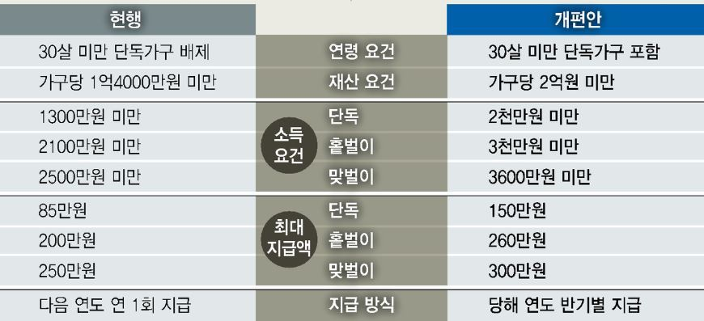

근로장려금 개편안

- 그림 출처 http://www.hani.co.kr/arti/economy/economy_general/860253.html

근로장려금(EITC) 신청현황

| 년도 | 가구수 | 금액(단위: 백만원) |
| --- | --- | --- |
| 2012 | 1,020,087 | 719,327 |
| 2013 | 1,060,405 | 967,151 |
| 2014 | 1,658,659 | 1,419,592 |
| 2015 | 1,738,297 | 1,320,465 |
| 2016 | 1,883,053 | 1,417,597 |

그렇다면 그동안 근로 관련 정책에 얼마만큼 예산을 투입했으며 국민소득 증가에 있어서 ‘소득주도 성장’ 정책의 영향을 얼마만큼 받았는지 궁금하다.

## 데이터와 관련된 전문지식

1. 분석하고자 하는 데이터가 많고, 또 계량분석을 통해 그영향력을 분석하는 만큼 통계적 오류 그리고 계량분석상에서 누락변수나 모형의 유의성 검정 관련 분석기법에 대해 알아야한다.

## 데이터 분석의 방향

국민소득의 대용변수로써 시계열자료의 근로 소득 10분위부터 1분위까지의 구성비 변화 그리고 근로정책 관련 재정지출의 비교를 통해 그 영향력을 분석한다. 나아가서 근로정책이 실제로 일자리창출에도 어느정도 영향을 미쳤는지 분석하여본다.

- 활용 데이터 : [국세청/3.종합소득세/3-3-1. 종합소득세 확정신고 인원 현황](http://stats.nts.go.kr/national/major_detail.asp?year=2017&catecode=A03019)